# 5.2 Sampling Distributions

## Sampling Error

We want to use a sample to learn something about a population, but no sample is perfect!

**Sampling error** is the error resulting from using a sample to estimate a population characteristic.

## Sampling Error

If we use a sample mean \(\bar{x}\) to estimate \(\mu\), chances are that \(\bar{x}\ne\mu\) (they might be close but… they might not be!). We will consider

- How close *is* \(\bar{x}\) to \(\mu\)?
- What if we took many samples and calculated \(\bar{x}\) many times?
  - How would that relate to \(\mu\)?
  - What would be the distribution of these values?

## Sampling Distribution

The distribution of a statistic (across all possible samples of size \(n\)) is called the **sampling distribution**.

For a variable \(x\) and given a sample size \(n\), the distribution of \(\bar{x}\) is called the **sampling distribution of the sample mean** or the **distribution of \(\boldsymbol{\bar{x}}\)**.

## Example

Suppose our population is the five starting players on a particular basketball team. We are interested in their heights (measures in inches). The full population data is

| Player | A | B | C | D | E |
| --- | --- | --- | --- | --- | --- |
| Height | 76 | 78 | 79 | 81 | 86 |

The population mean is \(\mu=80\).

## Example

Consider all possible samples of size \(n=2\):

| Sample | A,B | A,C | A,D | A,E | B,C | B,D | B,E | C,D | C,E | D,E |
| --- | --- | --- | --- | --- | --- | --- | --- | --- | --- | --- |
| \(\bar{x}\) | 77 | 77.5 | 78.5 | 81.0 | 78.5 | 79.5 | 82.0 | 80.0 | 82.5 | 83.5 |

There are 10 possible samples of size 2.

- Of these samples, 10% have means exactly equal to \(\mu\).
  - For a *random* sample of size 2, you’d have a 10% chance to find \(\bar{x}=\mu\).

In general, the larger the sample size, the smaller the sampling error tends to be in estimating \(\mu\) using \(\bar{x}\).

In practice, we have one sample and \(\mu\) is unknown.

## The sampling distribution of the sample mean

For the distribution of \(\bar{X}\)

- The mean of the distribution is \(\mu_{\bar{X}}=\mu\).
- The standard deviation is \(\sigma_{\bar{X}}=\sigma/\sqrt{n}\).

We refer to the standard deviation of a sampling distribution as **standard error**.

## Checkpoint

The mean living space for a detached single family home in the United States is 1742 ft\(^2\) with a standard deviation of 568 square feet. For samples of 25 homes, determine the mean and standard error of \(\bar{x}\).

## The Distribution of \(\bar{X}\)

The plots show (A) a random sample of 1000 from a Normal(100, 25) distribution and (B) the approximate sampling distribution of \(\bar{X}\) when X is Normal(100, 25).

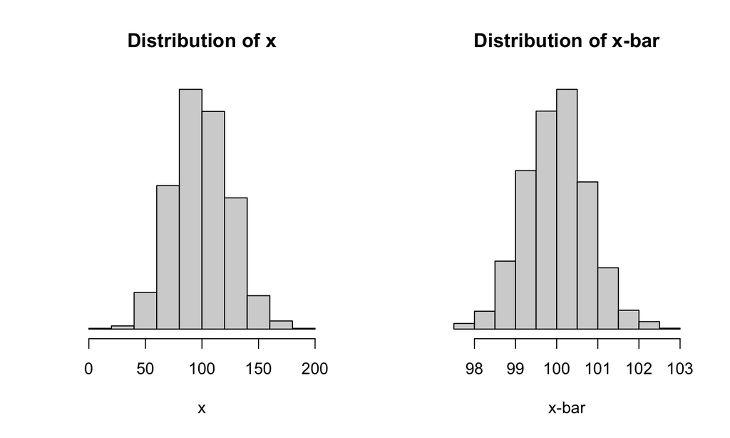

## The Distribution of \(\bar{X}\)

In fact, if \(X\) is Normal(\(\mu\), \(\sigma\)), then \(\bar{X}\) is Normal(\(\mu_{\bar{X}}=\mu\), \(\sigma_{\bar{X}}=\sigma/\sqrt{n}\)).

Surprisingly, we see a similar result for \(\bar{X}\) even when \(X\) is not normally distributed!

## The Central Limit Theorem

For relatively large sample sizes, the random variable \(\bar{X}\) is approximately normally distributed *regardless of the distribution of* \(X\): \[\bar{X}\text{ is Normal}(\mu_{\bar{X}}=\mu, \sigma_{\bar{X}}=\sigma/\sqrt{n}).\]

Notes

- This approximation improves with increasing sample size.
- In general, “relatively large” means sample sizes \(n \ge 30\).